# Exploring the BRFSS data

## 1. Data

### 1.1 Background

The Behavioral Risk Factor Surveillance System (BRFSS) is a United States' government program that is conducted by the Centers for Disease Control (CDC) in order to collect data on health-related risk behaviors and chronic health conditions of the US residents. Data from all 50 states as well as 3 U.S. territories and the District of Columbia is collected. The data is invaluable for activities that aim to develop health promotion in The U.S.

### 1.2 Data Collection

The data is collected at the local and state level by conducting telephone interviews. Annually, more than 400,000 adults are interviewed. The phone numbers of households are chosen randomly and then, a person in that household who is older than 18 is chosen randomly. Since 2011, cellular phone interviews are also conducted apart from land-line interviews. For this purpose, adults who live in a house or a college housing are chosen.

The questions are in the form of a questionnaire consisting of three sections, namely:

1. Core component  
   1.1 Fixed core: Fixed set of questions.  
   1.2 Rotating core: Two distinct sets of questions, each asked in alternating years.  
   1.3 Emerging core:  
   A set of up to five questions that are added to the fixed and rotating cores.  
   These include issues that are deemed important in the present or in the future.
2. Optional modules: Questions on specific topics (formulated by the CDC) that states may use.
3. State-added questions

The questions and collected data include topics such as health status, knowledge on certain health related matter, immunization information, sleep habits, tobacco use, accessibility to health services, alcohol consumption, sleep, cholesterol and hypertension awareness etc.

The data for this project is from the 2013 BRFSS survey.

### 1.3 Sampling and Scope of Inference

The BRFSS is an observational study because the data is collected in a way that does not interfere with how they arise. Simply put, this is a survey to collect data rather than an experiment to determine the relationship between two or more variables that the researchers could control.

The population of interest is the population of the U.S.

The sampling method is stratified random sampling. The strata are the states and the U.S. territories. A number of random telephone numbers are selected from each strata for the survey and then a random person from each household is chosen.

Due to the random nature of selecting individuals, the sample can be considered representative i.e. the findings of exploratory data analysis can be **generalized** to the population. Additionally, the relevant findings can be generalized to the each strata (i.e. the state or the territory) as well. This is because the individuals are random within the strata.

However, there is no random assignment of subjects (mainly because this is an observational study). Therefore **No causality** can be inferred from the findings. Only correlations or associations can be identified between variables.

Therefore, in general, the outcomes of exploratory data analyses on BRFSS data are **generalizable** and **correlational**.

#### 1.3.1 Sampling Biases

Despite the above discussion, certain types of sampling biases can exist in the data. For example, some people might be hesitant to disclose their health issues to a the interviewer. This is especially true in the case of mental health issues. As such questions are included in BRFSS, the sample can suffer from non-response bias which means only healthy people answer such questions.

Self-selection bias is an extension of non-response bias which can occur in BRFSS. In self-selection bias, only certain types of people would volunteer to participate. For instance, young people who are busy, females that are nursing or taking care of young children, individuals suffering from diseases might not participate in the survey. This would lead to a biased sample.

### 1.5 Objectives

Objectives of the this project are:

- To identify three research problems related to the data.
- To carry out Exploratory Data Analysis on these problems.

## 2. Research Questions

### 2.1 Research Question 1

Does gender has any influence on a person's ability to get medical attention when in need?

Variables:  
**medcost**: Was there a time in the past 12 months when you needed to see a doctor but could not because of cost?  
**sex**: Sex of the participants. Male or Female.

Rationale: Sex is an important issue when it comes to income of an individual. Even in some western, developed countries, the is a well known income difference between the two sexes. Therefore, sex can affect whether someone is able to afford to visit a doctor when they have a medical need.

### 2.2 Research Question 2

Is there a relationship between the number of hours of sleep and the number of days where the physical health is not good? Is the relationship (if any) confounded by the sex of the respondent?

Variables:  
**sex**: Sex of the respondent.  
**sleptim1** : On average, how many hours of sleep do you get in a 24-hour period?  
**physhlth** : how many days during the past 30 days was your physical health not good?

Rationale: Sleep is essential for health. This is a well-known fact. This research question aims to find whether there is a relationship between these two variable in the data set. Sex of an individual can confound the relationship (if any).

### 2.3 Research Question 3

Is there any relationship between heart attack and blood cholesterol level? Does age play a role in this relationship?

Variables:  
**cvdinfr4**: Has a medical professional ever told you that you had a heart attack or myocardial infarction?  
**toldhi2**: Has a medical professional ever told you that that your blood cholesterol is high?  
**X_age65yr**: Reported age in two categories: below and above 65 years.

Rationale: Heart attacks and blood cholesterol has a well-known relationship. In this research question, I attempt to check whether this is true for this sample. This relationship can be confounded by age of the individual. Therefore, whether the respondent is above or below 65 years of age is also considered.

## 3. Exploratory Data Analysis

Load necessary packages and data.

```r
library(ggplot2)
library(dplyr)
```

```r
load("brfss2013.RData")
```

### 3.1 Research Question 1:

We are trying to determine the relationship (if any) between the variables **sex** and **medcost**.

The two variables have the following forms.

```r
str(brfss2013$medcost)
```

```
##  Factor w/ 2 levels "Yes","No": 2 2 2 2 2 2 2 2 2 2 ...
```

```r
str(brfss2013$sex)
```

```
##  Factor w/ 2 levels "Male","Female": 2 2 2 2 1 2 2 2 1 2 ...
```

It appears that both **sex** and **medcost** are categorical variables. Former has two levels *Male* and *Female*, whereas the latter has levels *Yes* and *No*.

Let us check whether the variables have empty values (NA).

```r
brfss2013 %>% group_by(sex) %>% summarise(count = n())
```

```
## # A tibble: 3 x 2
##   sex     count
##   <fct>   <int>
## 1 Male   201313
## 2 Female 290455
## 3 <NA>        7
```

```r
brfss2013 %>% group_by(medcost) %>% summarise(count = n())
```

```
## # A tibble: 3 x 2
##   medcost  count
##   <fct>    <int>
## 1 Yes      60107
## 2 No      430447
## 3 <NA>      1221
```

We can see that both variables have "NA" values. But their frequencies are very small compared to the other values. Therefore, these can be ignored. These can represent "refused to answer" answers.  
Let us create a contingency table.

```r
sm_table <- table(brfss2013$sex, brfss2013$medcost, dnn=c('   sex   ', '     medcost'), useNA = 'no')
sm_table
```

```
##               medcost
##    sex       Yes     No
##    Male    21294 179504
##    Female  38811 250942
```

Let us add row and column sums.

```r
c_sm_table <- addmargins(sm_table, margin = c(1,2))
c_sm_table
```

```
##               medcost
##    sex       Yes     No    Sum
##    Male    21294 179504 200798
##    Female  38811 250942 289753
##    Sum     60105 430446 490551
```

Even with sums, it is difficult to make a comparisons. Relative frequencies would be useful.

Let us get the relative frequencies (percentages) column-wise.

```r
# Column-wise percentages only.
rf_sm_table <- prop.table(sm_table, 2)

# Include sums of medcost categories as well.
rf_sm_table <- addmargins(rf_sm_table, margin = 1)
rf_sm_table
```

```
##               medcost
##    sex          Yes        No
##    Male   0.3542800 0.4170186
##    Female 0.6457200 0.5829814
##    Sum    1.0000000 1.0000000
```

**Important**: sums (totals) run column-wise only.

Let us create a bar chart to visually depict this data.

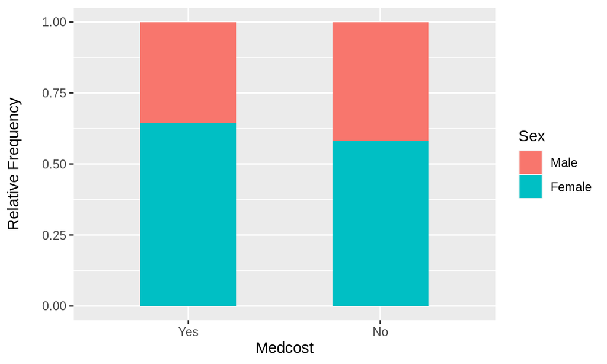

```r
# We only need the frequencies, not sums i.e. first two rows only.
frame_for_bar = data.frame(head(rf_sm_table, n = 2))

# Change the variable names (column names) to something easy to deal with.
colnames(frame_for_bar) <- c('Sex', 'Medcost', 'Frequency')

# Bar chart.
ggplot(data = frame_for_bar, aes(x = Medcost, y = Frequency, fill = Sex)) +
  geom_bar(stat='identity', width = 0.5) +
  labs(y = "Relative Frequency\n")
```

According to the data as well as the bar chart, it appears that out of the individuals who said *Yes* to the question "Was there a time in the past 12 months when you needed to see a doctor but could not because of cost?", about 64.6 % were females, while 35.4 % were males. Out of those who said *No*, around 58.3 % were females and 41.7 % were males.

When it came to affordability of seeing a doctor, women were the disadvantaged group. However, in the opposite case also women were the higher percentage. It appears that inability to see a doctor does not depend on the sex. There seems to be no relationship between the variables **sex** and **medcost**. A Chi-square test would be useful for in depth analysis.

### 3.2 Research Question 2:

Let us start with observing the structure of the **sleptim1** variable.

```r
str(brfss2013$sleptim1)
```

```
##  int [1:491775] NA 6 9 8 6 8 7 6 8 8 ...
```

How about extreme and nonsensical values?

```r
range(brfss2013$sleptim1, na.rm = TRUE)
```

```
## [1]   0 450
```

**sleptim1** is a numerical variable. It contains *NA* values. Additionally, it contains 0 and 450 which are improbable. Therefore, data has to be cleaned.

Similarly, let us take the **physhlth** variable.

```r
str(brfss2013$physhlth)
```

```
##  int [1:491775] 30 0 3 2 10 0 1 5 0 0 ...
```

```r
# NA values?
brfss2013 %>% filter(is.na(physhlth)) %>% summarise(count = n())
```

```
##   count
## 1 10957
```

**physhlth** is a numerical variable. It contains *NA* values. Therefore, the data has be cleaned with respect to this variable as well.

Let us extract the required variables and clean the data by filtering.

```r
# Get only the required columns (i.e. variables).
cleaned_data <- brfss2013[c('sleptim1', 'physhlth', 'sex')]

# Filter out unnecessary cases.
cleaned_data <- cleaned_data %>% filter(!is.na(sleptim1) & sleptim1 < 24 & !is.na(physhlth) &
                                          physhlth <= 30 & physhlth > 0 & sleptim1 > 0)
str(cleaned_data)
```

```
## 'data.frame':    173671 obs. of  3 variables:
##  $ sleptim1: int  9 8 6 7 6 3 7 6 6 10 ...
##  $ physhlth: int  3 2 10 1 5 30 10 3 3 30 ...
##  $ sex     : Factor w/ 2 levels "Male","Female": 2 2 1 2 2 1 2 2 1 2 ...
```

A histogram of **sleptim1** follows.

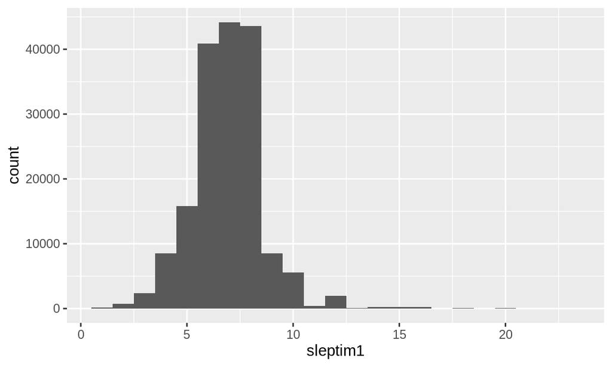

```r
ggplot(data = cleaned_data, aes(x = sleptim1)) + geom_histogram(binwidth = 1)
```

The distribution is unimodal and appears to be symmetric. Let us calculate some summary statistics.

```r
cleaned_data %>% select(sleptim1) %>% summarise(count = n(),
                                                  mean = mean(sleptim1),
                                                  median = median(sleptim1),
                                                  standard_deviation = sd(sleptim1),
                                                  IQR = IQR(sleptim1))
```

```
##    count     mean median standard_deviation IQR
## 1 173671 6.914868      7           1.693916   2
```

The fact that mean and median are very close implies that the distribution is symmetric.  
A histogram for the distribution of **physhlth** variable is given below.

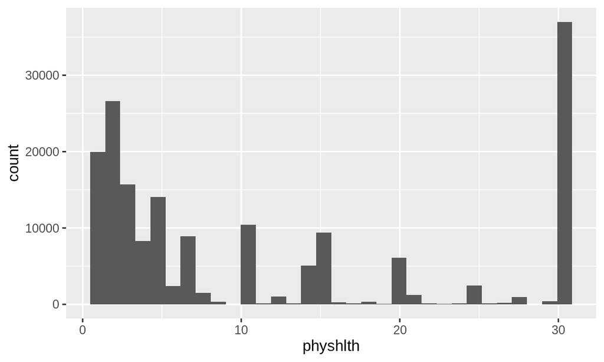

```r
ggplot(data = cleaned_data, aes(x = physhlth)) + geom_histogram(binwidth = .95)
```

This is a multi-modal, right skewed asymmetric distribution. Below are some summary statistics. Unusually high frequencies are seen for 30 days.

```r
cleaned_data %>% select(physhlth) %>% summarise(count = n(),
                                                  mean = mean(physhlth),
                                                  median = median(physhlth),
                                                  standard_deviation = sd(physhlth),
                                                  IQR = IQR(physhlth))
```

```
##    count     mean median standard_deviation IQR
## 1 173671 11.73155      6           11.11248  18
```

The wide difference between the mean and the median is characteristic of an asymmetric distribution.

Let us plot **phyhlth** vs. **sleptim1**.

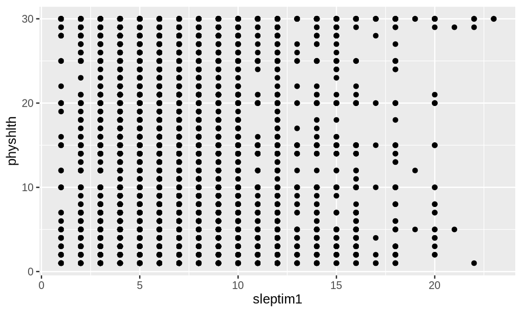

```r
ggplot(data = cleaned_data, aes(x = sleptim1, y = physhlth)) + geom_point()
```

There appears to be no meaningful relationship between the amount of sleep and the physical health. For a given amount of sleep, there are individuals who felt physically fit the whole month as well as individuals who felt physically unfit the whole month. Most of the people that slept more than 20 hours a day showed extreme values for **physhlth** variable i.e. they reported nearly 30 days of physical unfitness or nearly 0 days.

Let us now attempt to find the role **sex** plays in all this.

```r
cleaned_data_males <- cleaned_data %>% filter(sex == 'Male')
cleaned_data_females <- cleaned_data %>% filter(sex =='Female')
```

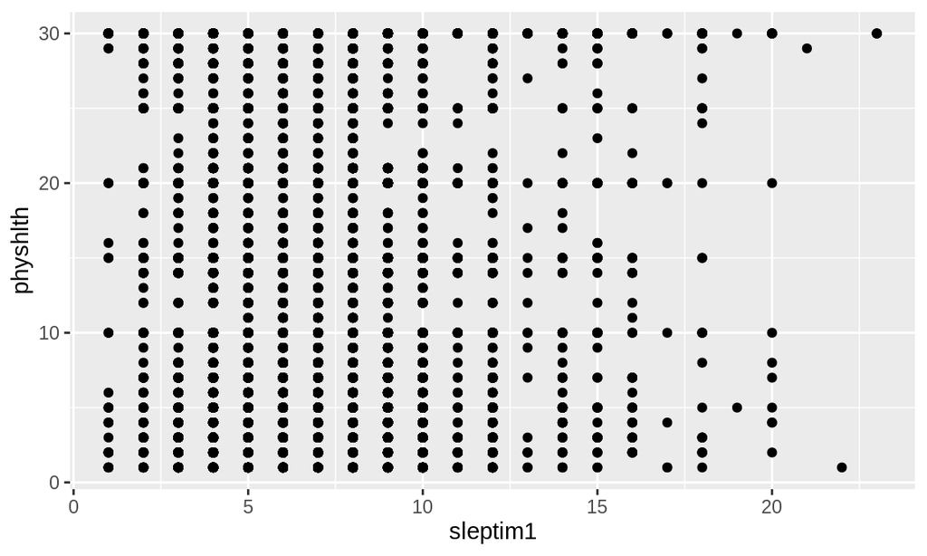

```r
ggplot(data = cleaned_data_males, aes(x = sleptim1, y = physhlth)) + geom_point()
```

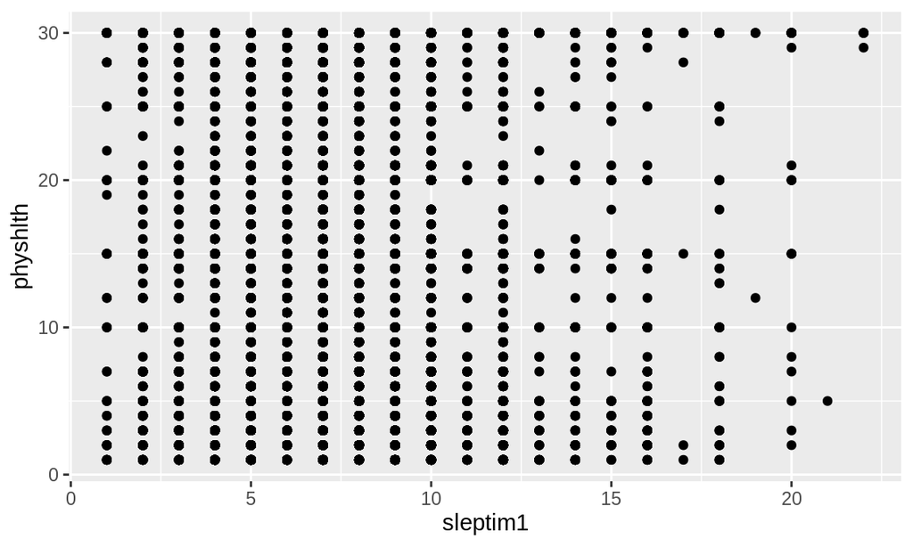

```r
ggplot(data = cleaned_data_females, aes(x = sleptim1, y = physhlth)) + geom_point()
```

Even with respect to the **sex**, there appears to be no difference.

### 3.3 Research Question 3:

Let us start by looking at the structure of the variables.

```r
str(brfss2013$cvdinfr4)
```

```
##  Factor w/ 2 levels "Yes","No": 2 2 2 2 2 2 2 2 2 2 ...
```

```r
str(brfss2013$toldhi2)
```

```
##  Factor w/ 2 levels "Yes","No": 1 2 2 1 2 1 2 1 1 2 ...
```

```r
str(brfss2013$X_age65yr)
```

```
##  Factor w/ 2 levels "Age 18 to 64",..: 1 1 1 1 2 1 1 1 1 2 ...
```

Any irrelevant values such as *NA*?

```r
brfss2013 %>% filter(is.na(cvdinfr4)) %>% summarise(cvdinfr4_NAs = n())
```

```
##   cvdinfr4_NAs
## 1         2587
```

```r
brfss2013 %>% filter(is.na(toldhi2)) %>% summarise(toldhi2_NAs = n())
```

```
##   toldhi2_NAs
## 1       71662
```

```r
brfss2013 %>% filter(is.na(X_age65yr)) %>% summarise(X_age65yr_NAs = n())
```

```
##   X_age65yr_NAs
## 1          4732
```

All 3 variables are categorical and they contain *NA* values. Therefore, let us clean and extract the required variables only.

```r
# Extract.
q3_cleaned_data <- brfss2013[c('cvdinfr4', 'toldhi2', 'X_age65yr')]

# Clean.
q3_cleaned_data <- q3_cleaned_data %>% filter(!is.na(cvdinfr4) &
                                                !is.na(toldhi2) & !is.na(X_age65yr))
str(q3_cleaned_data)
```

```
## 'data.frame':    414146 obs. of  3 variables:
##  $ cvdinfr4 : Factor w/ 2 levels "Yes","No": 2 2 2 2 2 2 2 2 2 2 ...
##  $ toldhi2  : Factor w/ 2 levels "Yes","No": 1 2 2 1 2 1 2 1 1 2 ...
##  $ X_age65yr: Factor w/ 2 levels "Age 18 to 64",..: 1 1 1 1 2 1 1 1 1 2 ...
```

Let us create a contingency table with relative frequencies.

```r
hc_table <- table(q3_cleaned_data$toldhi2, q3_cleaned_data$cvdinfr4,
                  dnn=c('Heart attack', '  High cholesterol'))

# Percentages.
phc_table <- prop.table(hc_table, 2)

# Sums are only column-wise.
phc_table <- addmargins(phc_table, margin = 1)
```

Let us create a data frame for creating a bar chart on the data.

```r
# We only need the frequencies, not sums i.e. first two rows only.
q3_frame_for_bar = data.frame(head(phc_table, n = 2))

# Rename the columns for ease of use.
colnames(q3_frame_for_bar) <- c('Heart_attack', 'High_cholesterol', 'Frequency')

# The contingency table.
phc_table
```

```
##               High cholesterol
## Heart attack       Yes        No
##          Yes 0.7022261 0.4174925
##          No  0.2977739 0.5825075
##          Sum 1.0000000 1.0000000
```

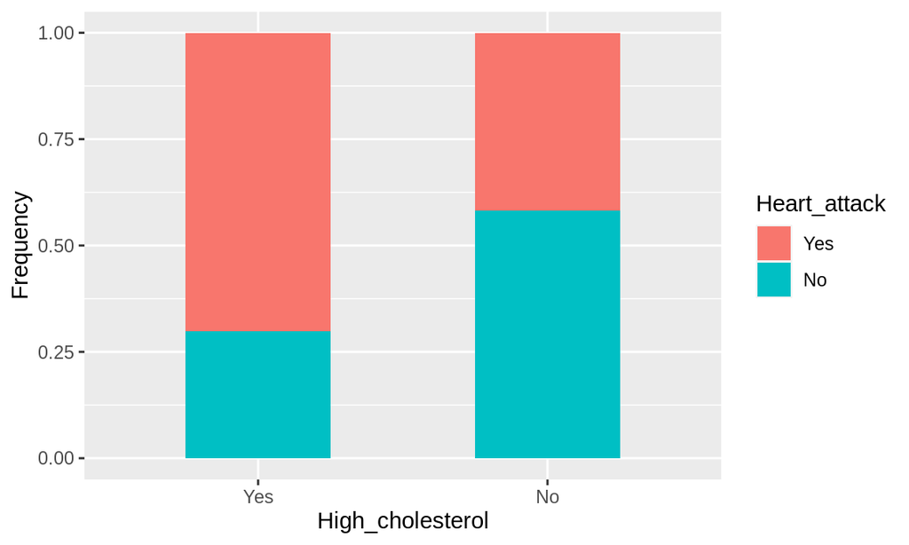

```r
# Bar chart.
ggplot(data = q3_frame_for_bar, aes(x = High_cholesterol, y = Frequency, fill = Heart_attack)) +
  geom_bar(stat = 'identity', width = 0.5)
```

From the contingency table as well as the bar chart, it is very clear that people with high cholesterol had a higher percent of heart attacks (about 70 %). Only 30 % of people who had higher cholesterol did not suffer from heart attacks. With respect to low blood cholesterol levels, the heart attack rates are around 42 % (yes) and 58 % (no). It is very clear that blood cholesterol level and heart attack prevalence is **associated**.

Next, assuming that blood cholesterol is mainly due to diet and it has no impact from a person's age, let us try to find whether prevalence of heart attacks has any relationship with the individual's age being above or below 65.

A contingency table between **X_age65yr** and **cvdinfr4** with relative frequencies.

```r
# Heart attack and age table.
ha_table <- table(q3_cleaned_data$X_age65yr, q3_cleaned_data$cvdinfr4,
                  dnn=c('  Age', '    Heart attack'))

# Percentages.
pha_table <- prop.table(ha_table, 2)

# Sums are only column-wise.
pha_table <- addmargins(pha_table, margin = 1)
pha_table
```

```
##                      Heart attack
##   Age                   Yes        No
##   Age 18 to 64    0.3479329 0.6576924
##   Age 65 or older 0.6520671 0.3423076
##   Sum             1.0000000 1.0000000
```

Let us create a data frame for creating a bar chart using the data.

```r
# Only need the frequencies, not sums i.e. first two rows only.
q3_frame_for_bar_2 = data.frame(head(pha_table, n = 2))

# Rename the columns for ease of use.
colnames(q3_frame_for_bar_2) <- c('Age', 'Heart_attack', 'Frequency')

# The contingency table.
pha_table
```

```
##                      Heart attack
##   Age                   Yes        No
##   Age 18 to 64    0.3479329 0.6576924
##   Age 65 or older 0.6520671 0.3423076
##   Sum             1.0000000 1.0000000
```

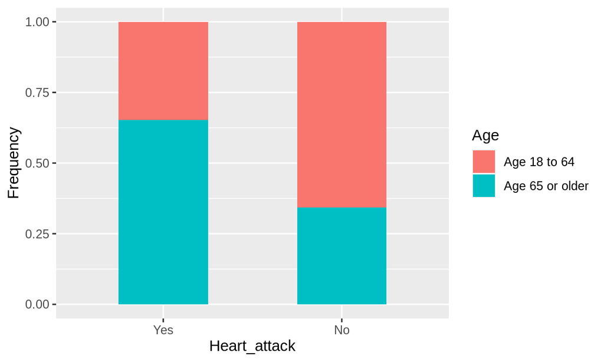

```r
# Bar chart.
ggplot(data = q3_frame_for_bar_2, aes(x = Heart_attack, y = Frequency, fill = Age)) +
  geom_bar(stat = 'identity', width = 0.5)
```

From these results, it is clear that above 65 % who had heart attacks were above 65 years old, whereas only 35 % were between 18 and 64. However, among the people who did not have a heart attack, only 34 % were above 65 years. 66 % of respondents who did not suffer a cardiac incident were below 65 years old.

It is clear that there is a strong correlation between the variables **X_age65yr** and **cvdinfr4**. Therefore, earlier analysis between **toldhi2** and **cvdinfr4** could have been confounded by **X_age65yr**. Therefore, a more sophisticated and careful analysis is necessary to come to better conclusions.